# Tidybiology Final Project

Timothy Smith

October 21, 2019

## Load libraries, such as tidyverse and tidybiology

```r
library(tidyverse)
library(tidybiology)
#uncomment (or select) to clear environment; good for provenance
rm(list=ls())
```

## Import data

I decided to look into relationships between coding and non coding regions of the human genome. To do this, I loaded the chromosome summary data, which was originally scraped from [a Wikipedia entry about the human chromosome](https://en.wikipedia.org/wiki/Human_chromosome).

```r
data(chromosome)
#IMPORT YOUR DATA
#MAKE SURE TO GET THE CODE CHUNK OPTIONS SET
```

## Take a `glimpse` into the data in the dataframe

Here we see information on the total number of protein coding genes as well as a variety of non coding forms of RNA. To do this, I first wanted to create a new column that is the sum of all types of non coding RNA called ncRNA.

```r
glimpse(chromosome)
```

```
## Observations: 24
## Variables: 14
## $ id                     <fct> 1, 2, 3, 4, 5, 6, 7, 8, 9, 10, 11, 12, 13…
## $ length_mm              <dbl> 85, 83, 67, 65, 62, 58, 54, 50, 48, 46, 4…
## $ basepairs              <dbl> 248956422, 242193529, 198295559, 19021455…
## $ variations             <dbl> 12151146, 12945965, 10638715, 10165685, 9…
## $ protein_codinggenes    <int> 2058, 1309, 1078, 752, 876, 1048, 989, 67…
## $ pseudo_genes           <int> 1220, 1023, 763, 727, 721, 801, 885, 613,…
## $ totallongnc_rna        <int> 1200, 1037, 711, 657, 844, 639, 605, 735,…
## $ totalsmallnc_rna       <int> 496, 375, 298, 228, 235, 234, 208, 214, 1…
## $ mi_rna                 <int> 134, 115, 99, 92, 83, 81, 90, 80, 69, 64,…
## $ r_rna                  <int> 66, 40, 29, 24, 25, 26, 24, 28, 19, 32, 2…
## $ sn_rna                 <int> 221, 161, 138, 120, 106, 111, 90, 86, 66,…
## $ sno_rna                <int> 145, 117, 87, 56, 61, 73, 76, 52, 51, 56,…
## $ miscnc_rna             <int> 192, 176, 134, 104, 119, 105, 143, 82, 96…
## $ centromereposition_mbp <dbl> 125.0, 93.3, 91.0, 50.4, 48.4, 61.0, 59.9…
```

```r
#DEPENDING ON DATA, NOT TOTALLY NECESSARY
```

## EDA

EXPLORATORY DATA ANALYSIS

```r
chromosome <- chromosome %>%
  mutate(ncRNA = totallongnc_rna + totalsmallnc_rna + miscnc_rna)
```

## EDA Graph

From this graph, we can see there is a clear relationship between the number of protein coding genes and ncRNA.

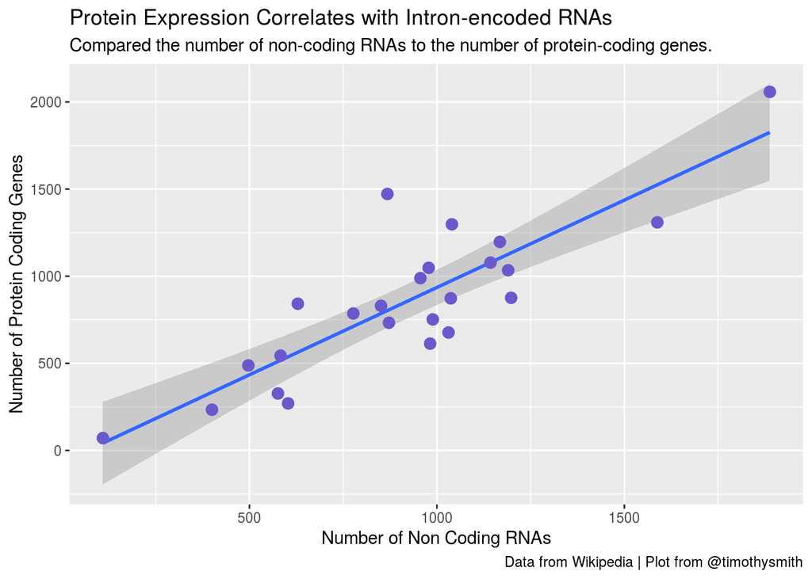

```r
ggplot(chromosome, aes(x = ncRNA, y = protein_codinggenes)) +
  geom_smooth(formula = y ~ x, method =lm, se = TRUE) +
  geom_point(color = "slateblue3", size = 3) +
  labs(x = "Number of Non Coding RNAs", y = "Number of Protein Coding Genes", title = "Protein Expression Correlates with Intron-encoded RNAs", subtitle = "Compared the number of non-coding RNAs to the number of protein-coding genes.", caption = "Data from Wikipedia | Plot from @timothysmith") +
  theme_gray() +
  NULL
```

## Acknolwedgements

I would like to thank Alan Rosales for being my seat and coffee buddy. I would like to thank Dr. Hirschey for this exciting introduction to R. Though it was a little difficult as someone without experience, it was a great introduction and I look forward to working with it in the future.

```r
#You can remove an item from sessionInfo(), which is a list with a class attribute, by printing the resulting object omitting one of the list items (omitted list of packages installed, but not loaded)
```